# Assignment 4: Outlier detection

## Bike Rental case study

This dataset contains the hourly and daily count of rental bikes between years 2011 and 2012 in Capital bikeshare system with the corresponding weather and seasonal information.

- Associated Tasks: Regression
- Number of Attributes: 16

https://archive.ics.uci.edu/ml/datasets/Bike+Sharing+Dataset

#### 1. load the csv bike rental data into a sas dataset

- use proc import to load csv data into sas dataset
- print the first five observations

```sas
libname mylib '/folders/myfolders/Assignments/';
PROC IMPORT DATAFILE='/folders/myfolders/Assignments/data/day.csv'
    DBMS=CSV
    OUT=mylib.bikeday;
    GETNAMES=YES;
RUN;

proc print data =mylib.bikeday (obs=5);
run;
```

Possible outliers

| Obs | instant | dteday | season | yr | mnth | holiday | weekday | workingday | weathersit | temp | atemp | hum | windspeed | casual | registered | cnt |
| --- | --- | --- | --- | --- | --- | --- | --- | --- | --- | --- | --- | --- | --- | --- | --- | --- |
| 1 | 1 | 2011-01-01 | 1 | 0 | 1 | 0 | 6 | 0 | 2 | 0.344167 | 0.363625 | 0.805833 | 0.160446 | 331 | 654 | 985 |
| 2 | 2 | 2011-01-02 | 1 | 0 | 1 | 0 | 0 | 0 | 2 | 0.363478 | 0.353739 | 0.696087 | 0.248539 | 131 | 670 | 801 |
| 3 | 3 | 2011-01-03 | 1 | 0 | 1 | 0 | 1 | 1 | 1 | 0.196364 | 0.189405 | 0.437273 | 0.248309 | 120 | 1229 | 1349 |
| 4 | 4 | 2011-01-04 | 1 | 0 | 1 | 0 | 2 | 1 | 1 | 0.2 | 0.212122 | 0.590435 | 0.160296 | 108 | 1454 | 1562 |
| 5 | 5 | 2011-01-05 | 1 | 0 | 1 | 0 | 3 | 1 | 1 | 0.226957 | 0.22927 | 0.436957 | 0.1869 | 82 | 1518 | 1600 |

#### 2. use proc means to examine the list of variables, their minimum and maximum

```sas
proc means data=mylib.bikeday;
run;
```

Possible outliers

The MEANS Procedure

| Variable | N | Mean | Std Dev | Minimum | Maximum |
| --- | --- | --- | --- | --- | --- |
| instant dteday season yr mnth holiday weekday workingday weathersit temp atemp hum windspeed casual registered cnt | 731 731 731 731 731 731 731 731 731 731 731 731 731 731 731 731 | 366.0000000 18993.00 2.4965800 0.5006840 6.5198358 0.0287278 2.9972640 0.6839945 1.3953488 0.4953848 0.4743540 0.6278941 0.1904862 848.1764706 3656.17 4504.35 | 211.1658116 211.1658116 1.1108071 0.5003419 3.4519128 0.1671547 2.0047869 0.4652334 0.5448943 0.1830510 0.1629612 0.1424291 0.0774979 686.6224883 1560.26 1937.21 | 1.0000000 18628.00 1.0000000 0 1.0000000 0 0 0 1.0000000 0.0591304 0.0790696 0 0.0223917 2.0000000 20.0000000 22.0000000 | 731.0000000 19358.00 4.0000000 1.0000000 12.0000000 1.0000000 6.0000000 1.0000000 3.0000000 0.8616670 0.8408960 0.9725000 0.5074630 3410.00 6946.00 8714.00 |

#### Histogram of the variable hum

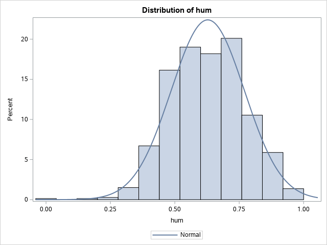

```sas
title 'Distribution of hum';
  proc sgplot data=mylib.bikeday;
  histogram hum;
  density hum;
run;
```

#### Box plot of the variable hum

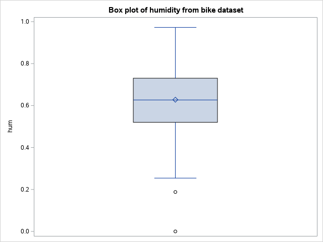

```sas
title "Box plot of humidity from bike dataset";
proc sgplot data=mylib.bikeday;
   vbox hum;
run;
```

#### 3. Output the outliers for the variable hum based on 2 standard deviation

As the distribution of the var hum is close to a normal distribution, then we can detect outliers using the standard deviation method.

Refer to Program 5.1 in Chapter 5

```sas
*Use PROC MEANS to Output means and standard deviations to a data set;
proc means data=mylib.bikeday noprint ;
    var hum;
   output out=Mean_Std(drop=_type_ _freq_)
          mean=
          std= / autoname;
run;

title "Outliers for hum Based on 2 Standard Deviations";
data _null_;
   file print;
   set mylib.bikeday (keep=instant hum );
   ***bring in the means and standard deviations;
   if _n_ = 1 then set Mean_Std;

   if hum lt hum_Mean - 2*hum_StdDev and not missing(hum) then put "low " instant= hum=;
   else if hum gt hum_Mean + 2*hum_StdDev then put "high " instant= hum=;
run;
```

Outliers for hum Based on 2 Standard Deviations

```
high instant=36 hum=0.929167
low instant=46 hum=0.314348
low instant=50 hum=0.187917
low instant=62 hum=0.318333
high instant=65 hum=0.948261
low instant=69 hum=0
low instant=87 hum=0.302174
low instant=88 hum=0.314167
high instant=90 hum=0.918333
high instant=134 hum=0.9225
low instant=153 hum=0.305
high instant=250 hum=0.917083
high instant=251 hum=0.939565
high instant=266 hum=0.9725
high instant=320 hum=0.93
high instant=326 hum=0.9625
high instant=340 hum=0.949583
high instant=341 hum=0.970417
low instant=394 hum=0.31125
low instant=452 hum=0.29
low instant=463 hum=0.254167
low instant=464 hum=0.275833
low instant=465 hum=0.3175
low instant=678 hum=0.333478
high instant=710 hum=0.925
```

#### 4. Output the outliers for the variable hum based on the interquantile range method.

Refer to program 5.8 from chapter 5, print Q1, Q3 and the Interquantile range (IQR) and output the outliers for hum using the interquantile range method

```sas
title "Detect Outliers Based on Interquartile Range";
proc means data=mylib.bikeday noprint;
   var hum;
   output out=Tmp (drop=_type_ _freq_)
          Q1=
          Q3=
          QRange= / autoname;
run;
title "Quartiles and IQR for hum";
proc print data=Tmp;
run;

title "Possible outliers";
data _null_;
   file print;
   set mylib.bikeday(keep=instant hum);
   if _n_ = 1 then set Tmp;
   if hum le hum_Q1 - 1.5*hum_QRange and not missing(hum) or
      hum ge hum_Q3 + 1.5*hum_QRange then
      put "Possible Outlier for instant " instant "Value of hum is " hum;
run;
```

Quartiles and IQR for hum

| Obs | hum_Q1 | hum_Q3 | hum_QRange |
| --- | --- | --- | --- |
| 1 | 0.52 | 0.730417 | 0.210417 |

Possible outliers

```
Possible Outlier for instant 50 Value of hum is 0.187917
Possible Outlier for instant 69 Value of hum is 0
```

#### 5. Do you see any risk in removing these outliers? justify your answer.

Modify your code of the previous question and delete the outliers. Give the dataset a new name bike_OutliersRemoved.

```sas
data mylib.bike_OutliersRemoved;
   file print;
   set mylib.bikeday;
   if _n_ = 1 then set Tmp;
   if hum le hum_Q1 - 1.5*hum_QRange and not missing(hum) or
      hum ge hum_Q3 + 1.5*hum_QRange then
      delete;
run;
```

#### 6. Box plot humidity from bike_OutliersRemoved

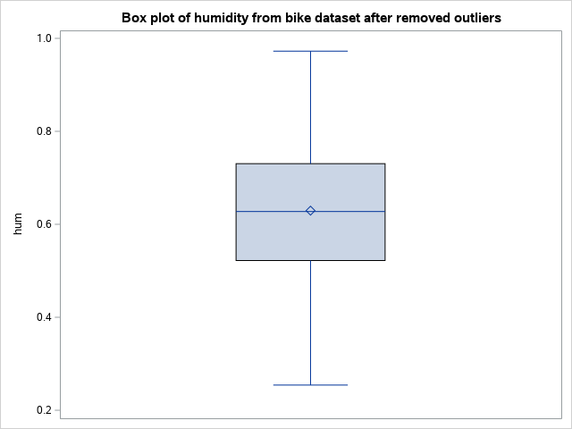

```sas
title "Box plot of humidity from bike dataset after removed outliers";
proc sgplot data=mylib.bike_OutliersRemoved;
   vbox hum;
run;
```

#### Histogram of the variable windspeed

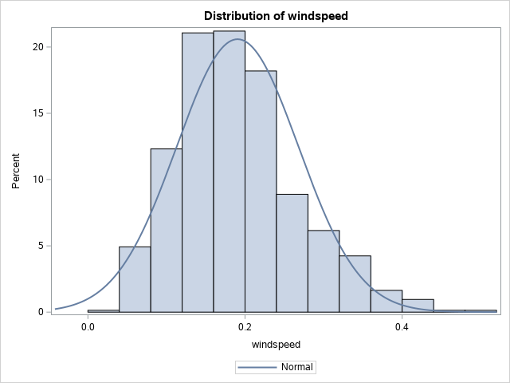

```sas
title 'Distribution of windspeed';
  proc sgplot data=mylib.bikeday;
  histogram windspeed;
  density windspeed;
run;
```

#### Box plot of the variable windspeed

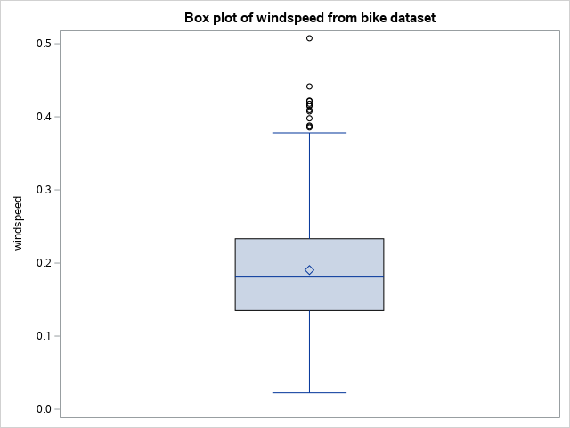

```sas
title "Box plot of windspeed from bike dataset";
proc sgplot data=mylib.bikeday;
   vbox windspeed;
run;
```

#### 7. Output the outliers for the variable windspeed based on the interquantile range method.

```sas
title "Detect Outliers Based on Interquartile Range";
proc means data=mylib.bikeday noprint;
   var windspeed;
   output out=Tmp (drop=_type_ _freq_)
          Q1=
          Q3=
          QRange= / autoname;
run;
title "Quartiles and IQR for windspeed";
proc print data=Tmp;
run;

title "Possible outliers";
data _null_;
   file print;
   set mylib.bikeday(keep=instant windspeed);
   if _n_ = 1 then set Tmp;
   if windspeed le windspeed_Q1 - 1.5*windspeed_QRange and not missing(windspeed) or
      windspeed ge windspeed_Q3 + 1.5*windspeed_QRange then
      put "Possible Outlier for instant " instant "Value of windspeed is " windspeed;
run;
```

Quartiles and IQR for windspeed

| Obs | windspeed_Q1 | windspeed_Q3 | windspeed_QRange |
| --- | --- | --- | --- |
| 1 | 0.13495 | 0.233221 | 0.098271 |

Possible outliers

```
Possible Outlier for instant 45 Value of windspeed is 0.417908
Possible Outlier for instant 50 Value of windspeed is 0.507463
Possible Outlier for instant 94 Value of windspeed is 0.385571
Possible Outlier for instant 95 Value of windspeed is 0.388067
Possible Outlier for instant 293 Value of windspeed is 0.422275
Possible Outlier for instant 383 Value of windspeed is 0.415429
Possible Outlier for instant 408 Value of windspeed is 0.409212
Possible Outlier for instant 421 Value of windspeed is 0.421642
Possible Outlier for instant 433 Value of windspeed is 0.441563
Possible Outlier for instant 434 Value of windspeed is 0.4148
Possible Outlier for instant 451 Value of windspeed is 0.386821
Possible Outlier for instant 667 Value of windspeed is 0.398008
Possible Outlier for instant 722 Value of windspeed is 0.407346
```

#### 8. Do you see any risk in removing the windspeed outliers found based on interquantile range method? justify your answer.

Answer here: The outliers might not be the errors. Base on the type of data collected, there may be a wide spread in value.